# Perfect Plots: Treemap

An old Chinese proverb says: one picture says more than one thousands words. One good plot can rescue entire presentation. One poor picture can drown down all good speech. After plenty of shame appointment and boring presentations I decided to improve my tools of visualisation.

```python
import squarify
import pandas as pd
import matplotlib.pyplot as plt

df1 = pd.read_csv('c:/11/freeFormResponses.csv', skiprows = 1)
```

```python
headers = ['Duration (in seconds)', 'Gender', 'Gender2','Age','Country','Education', 'Major_undergraduate','Recent_role', 'Recent_role2', 'Industry','Industry2' ,'Years_of_experience', 'compensation$USD']
df = pd.read_csv('c:/11/multipleChoiceResponses.csv', usecols=[0,1,2,3,4,5,6,7,8,9,10,11,12], header=None, names=headers, skiprows=2)
df.head(4)
```

|  | Duration (in seconds) | Gender | Gender2 | Age | Country | Education | Major_undergraduate | Recent_role | Recent_role2 | Industry | Industry2 | Years_of_experience | compensation$USD |
| --- | --- | --- | --- | --- | --- | --- | --- | --- | --- | --- | --- | --- | --- |
| 0 | 710 | Female | -1 | 45-49 | United States of America | Doctoral degree | Other | Consultant | -1 | Other | 0 | NaN | NaN |
| 1 | 434 | Male | -1 | 30-34 | Indonesia | Bachelor’s degree | Engineering (non-computer focused) | Other | 0 | Manufacturing/Fabrication | -1 | 5-10 | 10-20,000 |
| 2 | 718 | Female | -1 | 30-34 | United States of America | Master’s degree | Computer science (software engineering, etc.) | Data Scientist | -1 | I am a student | -1 | 0-1 | 0-10,000 |
| 3 | 621 | Male | -1 | 35-39 | United States of America | Master’s degree | Social sciences (anthropology, psychology, soc... | Not employed | -1 | NaN | -1 | NaN | NaN |

```python
df.drop(['Gender2','Recent_role2','Industry2'], axis=1, inplace=True)
```

### Correcting data

Every time when we want to do plot we will need to check and improve data. Especially check of unique occurrences and elimination of minority of rubbish and NaN cells (lack of data).

```python
df.isnull().sum()
```

```
Duration (in seconds)       0
Gender                      0
Age                         0
Country                     0
Education                 421
Major_undergraduate       912
Recent_role               959
Industry                 2174
Years_of_experience      2758
compensation$USD         3674
dtype: int64
```

```python
df.dtypes
```

```
Duration (in seconds)     int64
Gender                   object
Age                      object
Country                  object
Education                object
Major_undergraduate      object
Recent_role              object
Industry                 object
Years_of_experience      object
compensation$USD         object
dtype: object
```

Very important is reduction of the class or join some similar groups if it is not bad for the project.

```python
df['Gender']=df['Gender'].replace('Prefer to self-describe', 'Prefer not to say')
```

```python
df.Education.value_counts(dropna = False)
```

```
Master’s degree                                                      10855
Bachelor’s degree                                                     7083
Doctoral degree                                                       3357
Some college/university study without earning a bachelor’s degree      967
Professional degree                                                    599
NaN                                                                    421
I prefer not to answer                                                 345
No formal education past high school                                   232
Name: Education, dtype: int64
```

We can get assumption if somebody didn't answer he didn't want to give information: 'I prefer not to answer'.

```python
import numpy as np

df['Education']=df['Education'].replace(np.NaN, 'I prefer not to answer')
```

```python
df.Education.value_counts(dropna = False)
```

```
Master’s degree                                                      10855
Bachelor’s degree                                                     7083
Doctoral degree                                                       3357
Some college/university study without earning a bachelor’s degree      967
I prefer not to answer                                                 766
Professional degree                                                    599
No formal education past high school                                   232
Name: Education, dtype: int64
```

```python
df.Education.isnull().sum()
```

```
0
```

```python
df.Major_undergraduate.value_counts(dropna = False)
```

```
Computer science (software engineering, etc.)                    9430
Engineering (non-computer focused)                               3705
Mathematics or statistics                                        2950
A business discipline (accounting, economics, finance, etc.)     1791
Physics or astronomy                                             1110
Information technology, networking, or system administration     1029
NaN                                                               912
Medical or life sciences (biology, chemistry, medicine, etc.)     871
Other                                                             770
Social sciences (anthropology, psychology, sociology, etc.)       554
Humanities (history, literature, philosophy, etc.)                269
Environmental science or geology                                  253
I never declared a major                                          128
Fine arts or performing arts                                       87
Name: Major_undergraduate, dtype: int64
```

Rozumiem, że NaN i 'Other' jest wtedy, gdy ktoś nie chce zadeklarować swojej specjalizacji:'I never declared a major'

```python
df['Major_undergraduate']=df['Major_undergraduate'].replace(np.NaN, 'I never declared a major')
df['Major_undergraduate']=df['Major_undergraduate'].replace('Other', 'I never declared a major')
```

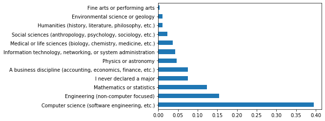

```python
df.Major_undergraduate.value_counts(dropna = False, normalize=True).plot(kind='barh')
```

```python
df.Recent_role.value_counts(dropna=False)
```

```
Student                    5253
Data Scientist             4137
Software Engineer          3130
Data Analyst               1922
Other                      1322
Research Scientist         1189
NaN                         959
Not employed                842
Consultant                  785
Business Analyst            772
Data Engineer               737
Research Assistant          600
Manager                     590
Product/Project Manager     428
Chief Officer               360
Statistician                237
DBA/Database Engineer       145
Developer Advocate          117
Marketing Analyst           115
Salesperson                 102
Principal Investigator       97
Data Journalist              20
Name: Recent_role, dtype: int64
```

```python
df['Recent_role']=df['Recent_role'].replace(np.NaN, 'Other')
```

### Poland in data

Because I am from Poland, most interesting data for me is information from my country. I separate data about Poland from original data.

```python
PL= df[df.Country=='Poland']
```

```python
Z5 = PL.pivot_table(index=['Major_undergraduate'], values='Age',aggfunc='count').sort_values('Age', ascending=False)
Z5.head(10)
```

| Major_undergraduate | Age |
| --- | --- |
| Computer science (software engineering, etc.) | 112 |
| Mathematics or statistics | 52 |
| A business discipline (accounting, economics, finance, etc.) | 34 |
| Physics or astronomy | 24 |
| Engineering (non-computer focused) | 22 |
| I never declared a major | 17 |
| Information technology, networking, or system administration | 14 |
| Social sciences (anthropology, psychology, sociology, etc.) | 12 |
| Medical or life sciences (biology, chemistry, medicine, etc.) | 7 |
| Humanities (history, literature, philosophy, etc.) | 4 |

### The Treemap

I came across this publication and decided to do Treemap by this way. https://www.machinelearningplus.com/plots/top-50-matplotlib-visualizations-the-master-plots-python/

```python
PPL=Z5.reset_index()
PPL.head(5)
```

|  | Major_undergraduate | Age |
| --- | --- | --- |
| 0 | Computer science (software engineering, etc.) | 112 |
| 1 | Mathematics or statistics | 52 |
| 2 | A business discipline (accounting, economics, ... | 34 |
| 3 | Physics or astronomy | 24 |
| 4 | Engineering (non-computer focused) | 22 |

### Cut out too long descriptions

```python
PPL['Major_undergraduate']= PPL['Major_undergraduate'].str.split('(').apply(lambda x: x[0])
PPL['Major_undergraduate']
```

```
0                                     Computer science
1                             Mathematics or statistics
2                                A business discipline
3                                  Physics or astronomy
4                                          Engineering
5                              I never declared a major
6     Information technology, networking, or system ...
7                                      Social sciences
8                             Medical or life sciences
9                                           Humanities
10                     Environmental science or geology
Name: Major_undergraduate, dtype: object
```

### Adds numbers of occurrences to the descriptions

```python
label = PPL['Major_undergraduate'].to_list()
label = PPL.apply(lambda x: str(x[0]) + "\n (" + str(x[1]) + ")", axis=1)
label
```

```
0                             Computer science \n (112)
1                      Mathematics or statistics\n (52)
2                         A business discipline \n (34)
3                           Physics or astronomy\n (24)
4                                   Engineering \n (22)
5                       I never declared a major\n (17)
6     Information technology, networking, or system ...
7                               Social sciences \n (12)
8                       Medical or life sciences \n (7)
9                                     Humanities \n (4)
10               Environmental science or geology\n (3)
dtype: object
```

### To pull vectors of data from the pivot table

```python
PPL.reset_index()

label
sizes = PPL['Age'].to_list()

colors = ['#ff0000','#434343','#666666','#999999','#b7b7b7','#cccccc','#d9d9d9','#efefef','#ffffff','#f3f3f3']
```

```python
import squarify
import matplotlib.pyplot as plt
```

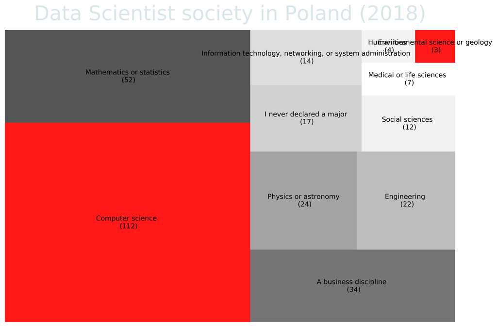

```python
# Plot
plt.figure(figsize=(12,8), dpi= 380)
squarify.plot(sizes=sizes, label=label, color=colors, alpha=0.9)

plt.title('Data Scientist society in Poland (2018)',  fontdict={'fontsize': 30, 'fontweight': 'medium', 'color':'#d0e0e3','alpha':0.8, 'y':1.02})
plt.axis('off') # brak numerów na osiach
plt.show()
```

# Trigger to create Treemap

To prepare perfect treemap first I will need to pull vectors of data from the pivot table.

### To pull vectors of data from the pivot table

```python
PPL.reset_index()

label = label = PPL['Major_undergraduate'].to_list()
label = PPL.apply(lambda x: str(x[0]) + "\n (" + str(x[1]) + ")", axis=1)
sizes = PPL['Age'].to_list()
title = 'Data Scientist society in Poland (2018)'

# https://yagisanatode.com/2019/08/06/google-apps-script-hexadecimal-color-codes-for-google-docs-sheets-and-slides-standart-palette/
#colors = ['#274e13','#6aa84f','#93c47d', '#b6d7a8','#d9ead3','#b7b7b7','#38761d'] #green
#colors = ['#0c343d','#134f5c','#45818e','#76a5af','#a2c4c9','#d0e0e3'] #cyan
#colors = ['#7f6000','#bf9000','#f1c232','#ffd966','#ffe599','#fff2cc'] #yelow
#colors = ['#4c1130','#a64d79','#c27ba0','#d5a6bd','#ead1dc','#741b47',] #magenta
#colors = ['#e6b8af','#b6d7a8','#e06666','#747574','#ffd966','#ffcc99','#ea9999']
#colors = ['#93c47d','#b6d7a8','#d9ead3','#d0e0e3','#a2c4c9','#76a5af']
colors = ['#c27ba0','#d5a6bd','#ead1dc','#ffffff','#a64d79','#d9d2e9','#b4a7d6'] #purple
#colors = ['#cfe2f3','#9fc5e8','#6fa8dc'] #blue
#colors = ['#d9ead3','#b6d7a8','#93c47d','#6aa84f']

#colors = ['#ff0000','#434343','#666666','#999999','#b7b7b7','#cccccc','#d9d9d9','#efefef','#ffffff','#f3f3f3'] #=> niemieckie czasopismo
```

```python
import squarify
import matplotlib.pyplot as plt

def Tmap(sizes, labels, colors, title):
    plt.figure(figsize=(12,8), dpi= 380)
    squarify.plot(sizes=sizes, label=label, color=colors, alpha=0.9)

    plt.title(title,  fontdict={'fontsize': 30, 'fontweight': 'medium', 'color':'#d0e0e3','alpha':0.9, 'y':1.02})
    plt.axis('off') # brak numerów na osiach
    plt.show()
```

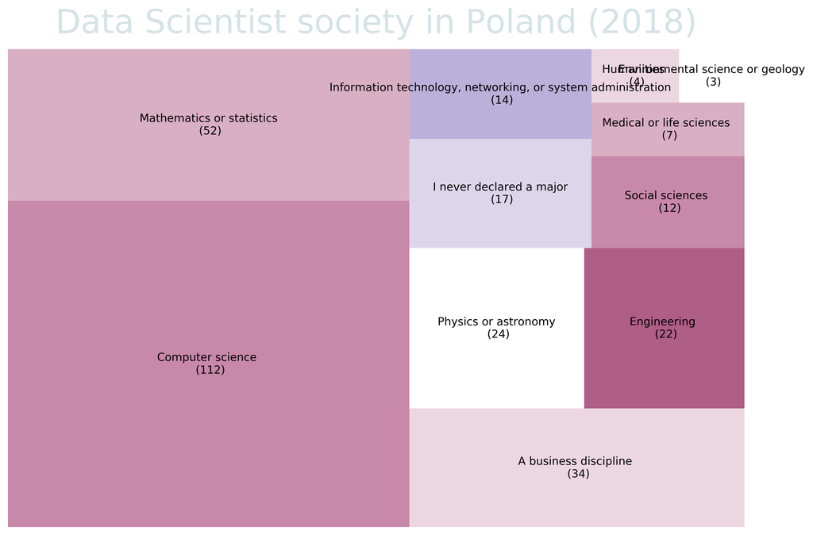

```python
Tmap(sizes, label, colors, title)
```